# MY470 - Class Week 8 - Programming

### Getting Started: Installing R and RStudio

Try knitting the `TestRMarkdown.Rmd` document. This means that you will need to have:

1. Installed R.
2. Installed RStudio.
3. Installed the **knitr** and **rmarkdown** packages. (When you open the `TestRMarkdown.Rmd` file, you should see a button for “Knit”. When you click on that, if the required packages are not yet installed, you should be prompted to install them.)
4. When this is successful, you will have converted a mixture of Markdown and R code into an HTML document. This is an important step, since the homework is in Rmarkdown.

For the rest of the class, you will need to open the file `MY470_wk8_class.Rmd` and work by modifying and knitting that (this!) file.

For your assignment, which you can find in `MY470_wk8_exercise.Rmd` in the assignment repository, you will need to follow a similar procedure. We will mark your responses based on the content of the .html file that you generate.

### R basics

Open RStudio and explore the programme. Make sure you can identify the `console`, the script editor, the `environment` window, the `packages` window and the `help` window.

Use the code below to create a vector of the integers 1 through 5. Examine the [RMarkdown](https://www.rstudio.com/wp-content/uploads/2015/03/rmarkdown-reference.pdf) code block below. This is the R equivalent of a Jupyter notebook “cell”.

```r
my_vec <- c(1, 2, 3, 4, 5)
```

In RStudio, you can insert code blocks in R (or Python) using the “Insert” button in the Source pane, or by typing the code fence triple backticks and the the `{r}` manually.

Multiply each element of your vector by 3, and assign the output to a new object. `print` the values of your new object.

```r
my_new_vec <- my_vec * 3
print(my_new_vec)
```

```
## [1]  3  6  9 12 15
```

1. Add together the two objects that you have created so far, `print`ing the result. Note that R operates on vectors element-wise.

```r
my_vec + my_new_vec
```

```
## [1]  4  8 12 16 20
```

2. Create a logical vector of length five, again using the `c()` function. Make sure that you have a mix of `TRUE` and `FALSE` values in the vector. Use the logical vector to subset the numeric vector that you created in question 2 and `print` the result.

```r
x <- c(TRUE, TRUE, FALSE, FALSE, TRUE)
#print(my_new_vec)
print(my_new_vec[x])
```

```
## [1]  3  6 15
```

```r
#x<-my_new_vec[x]
```

3. Subset to just the first two elements of the numeric vector that you created in question 2 and assign the result to have the name `my_short_vector`. Then, print that object.

```r
my_short_vector <- my_new_vec[1:2]
print(my_short_vector)
```

```
## [1] 3 6
```

4. Find the function to list all objects in your current environment. Can you see all the objects we just created?

```r
ls()
```

```
## [1] "my_new_vec"      "my_short_vector" "my_vec"          "x"
```

### Working with data frames

5. We will now work with a dataset that comes with R, called `state.x77`. The code below will add it to your workspace. Then, use the `str` and `summary` functions to examine this data frame. How do you interpret the output?

```r
df <- data.frame(state.x77)
df$state <- rownames(df)
str(df)
```

```
## 'data.frame':    50 obs. of  9 variables:
##  $ Population: num  3615 365 2212 2110 21198 ...
##  $ Income    : num  3624 6315 4530 3378 5114 ...
##  $ Illiteracy: num  2.1 1.5 1.8 1.9 1.1 0.7 1.1 0.9 1.3 2 ...
##  $ Life.Exp  : num  69 69.3 70.5 70.7 71.7 ...
##  $ Murder    : num  15.1 11.3 7.8 10.1 10.3 6.8 3.1 6.2 10.7 13.9 ...
##  $ HS.Grad   : num  41.3 66.7 58.1 39.9 62.6 63.9 56 54.6 52.6 40.6 ...
##  $ Frost     : num  20 152 15 65 20 166 139 103 11 60 ...
##  $ Area      : num  50708 566432 113417 51945 156361 ...
##  $ state     : chr  "Alabama" "Alaska" "Arizona" "Arkansas" ...
```

```r
summary(df)
```

```
##    Population        Income       Illiteracy       Life.Exp
##  Min.   :  365   Min.   :3098   Min.   :0.500   Min.   :67.96
##  1st Qu.: 1080   1st Qu.:3993   1st Qu.:0.625   1st Qu.:70.12
##  Median : 2838   Median :4519   Median :0.950   Median :70.67
##  Mean   : 4246   Mean   :4436   Mean   :1.170   Mean   :70.88
##  3rd Qu.: 4968   3rd Qu.:4814   3rd Qu.:1.575   3rd Qu.:71.89
##  Max.   :21198   Max.   :6315   Max.   :2.800   Max.   :73.60
##      Murder          HS.Grad          Frost             Area
##  Min.   : 1.400   Min.   :37.80   Min.   :  0.00   Min.   :  1049
##  1st Qu.: 4.350   1st Qu.:48.05   1st Qu.: 66.25   1st Qu.: 36985
##  Median : 6.850   Median :53.25   Median :114.50   Median : 54277
##  Mean   : 7.378   Mean   :53.11   Mean   :104.46   Mean   : 70736
##  3rd Qu.:10.675   3rd Qu.:59.15   3rd Qu.:139.75   3rd Qu.: 81162
##  Max.   :15.100   Max.   :67.30   Max.   :188.00   Max.   :566432
##     state
##  Length:50
##  Class :character
##  Mode  :character
##
##
##
```

6. Find the state with the highest and lowest population size. You will need to use the `order` function. You can check `?order` to find the documentation for this function.

```r
head(df[order(df$Population),], n=1) # lowest
```

```
##        Population Income Illiteracy Life.Exp Murder HS.Grad Frost   Area  state
## Alaska        365   6315        1.5    69.31   11.3    66.7   152 566432 Alaska
```

```r
tail(df[order(df$Population),], n=1) # highest
```

```
##            Population Income Illiteracy Life.Exp Murder HS.Grad Frost   Area
## California      21198   5114        1.1    71.71   10.3    62.6    20 156361
##                 state
## California California
```

```r
# another way of doing this:
newdf <- df[order(df$Population),]
newdf[1,]
```

```
##        Population Income Illiteracy Life.Exp Murder HS.Grad Frost   Area  state
## Alaska        365   6315        1.5    69.31   11.3    66.7   152 566432 Alaska
```

```r
newdf[50,]
```

```
##            Population Income Illiteracy Life.Exp Murder HS.Grad Frost   Area
## California      21198   5114        1.1    71.71   10.3    62.6    20 156361
##                 state
## California California
```

7. Finally, we will study the association between income per capita and education (% of high-school graduates). Compute a correlation coefficient between these two variables using the `cor` function. Then, create a scatterplot to illustrate visually this relationship using `plot`. As before, check the documentation for these functions to guide your work. If you want to see more information about the dataset, you can also type `?state.x77`.

```r
cor(df$Income, df$HS.Grad)
```

```
## [1] 0.6199323
```

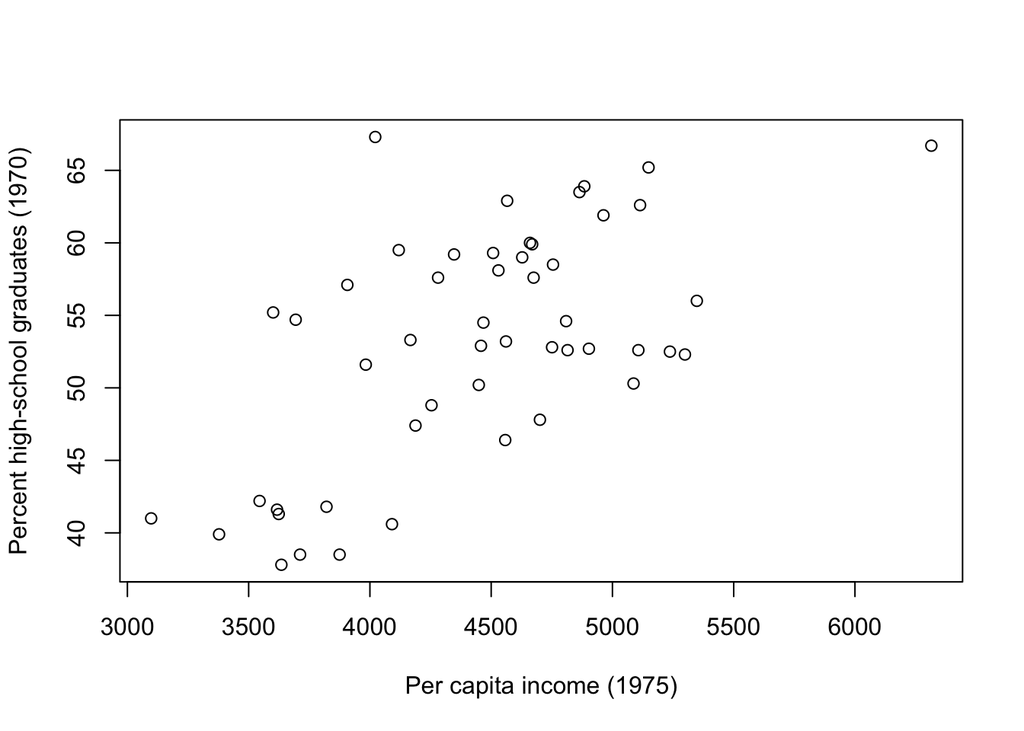

```r
plot(df$Income, df$HS.Grad,
     xlab="Per capita income (1975)",
     ylab="Percent high-school graduates (1970)")
```

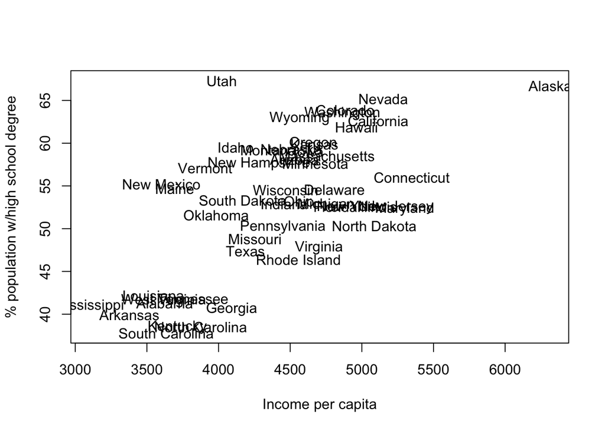

```r
# a different graph with state names instead of points:
plot(x=df$Income, y=df$HS.Grad,
     xlab="Income per capita",
     ylab="% population w/high school degree",
     type="n")
text(x=df$Income, y=df$HS.Grad, label=df$state)
```

#### Factorizing a categorical variable

Using the `mtcars` dataset, you need to transform the `am` variable into a factor with two levels, automatic and manual. Create a new column of `mtcars` called `am_factor` that is such a factor variable.

```r
data(mtcars) # this line of code will load the data into your workspace

mtcars$am_factor <- factor(ifelse(mtcars$am==1, "Automatic", "Manual"))
```

#### Computing aggregated statistics

Create a table with the median value of `mpg` for each value of `am_factor` using the `aggregate` function. Read the help page for `aggregate` to find information on how to achieve this.

```r
?aggregate
aggregate(mpg ~ am_factor, data=mtcars, FUN=median)
```

[output not shown]

Now replicate the code above, but this time with the average instead of the median.

```r
aggregate(mpg ~ am_factor, data=mtcars, FUN=mean)
```

```
##   am_factor      mpg
## 1 Automatic 24.39231
## 2    Manual 17.14737
```

### Working with functions

Write an R function that checks if a string is a palindrome. As you may recall from earlier in the term, a palindrome is a word or phrase that reads the same backward as forward. Note that you may run into some of the limitations of R when working with strings.

```r
is.palindrome <- function(string){
  # split into characters
  chars <- strsplit(string, split="")
  # convert to vector
  chars <- unlist(chars)
  # reverse characters
  rev_chars <- chars[length(chars):1]
  # paste into a single word
  rev_word <- paste(rev_chars, collapse="")
  return(
    ifelse(string==rev_word, "Is palindrome", "Is not palindrome")
  )
}

is.palindrome("racecar")
```

```
## [1] "Is palindrome"
```

```r
is.palindrome("level")
```

```
## [1] "Is palindrome"
```

```r
is.palindrome("programming")
```

```
## [1] "Is not palindrome"
```

### Loops

Loops in R have a similar structure as in python. For example:

```r
for (i in 1:10){
    print(i)
}
```

```
## [1] 1
## [1] 2
## [1] 3
## [1] 4
## [1] 5
## [1] 6
## [1] 7
## [1] 8
## [1] 9
## [1] 10
```

Write a loop to compute a [Fibonacci sequence](https://www.mathsisfun.com/numbers/fibonacci-sequence.html) in R for an input of length `n`. We realize that the Internet is full of solutions for this, and you are free to use one, but you should discuss why you chose this solution and what advantages it has over alternatives.

Compute and display the Fibonacci sequence of length 20 using your function.

```r
n <- 20

fibonacci <- function(n){
  fib <- c(0, 1, NA)
  for (i in 3:n){
    fib[i] <- fib[i-1] + fib[i-2]
  }
  return(fib)
}

fibonacci(n=20)
```

```
##  [1]    0    1    1    2    3    5    8   13   21   34   55   89  144  233  377
## [16]  610  987 1597 2584 4181
```